# Part II - (Presentation Title)

## (Visualization 3)

### Multivariate Exploration

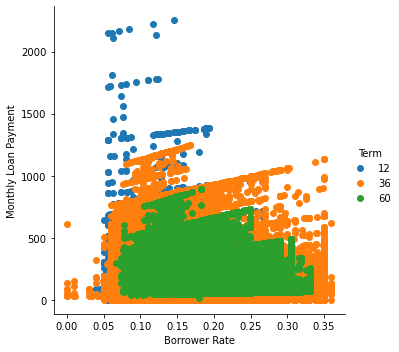

The borrower rate seems to be negatively correlated with monthly loan payment. Borrowers who chose 12 months plan are making higher monthly loan payments and their rate of borrowing (The Borrower's interest rate for the loan) is also low (between 0.05 and 0.18). On other hand borrowes who take 36 months and 60 months term make lower monthly loan payments and their Borrower's interest rate for the loan is high.

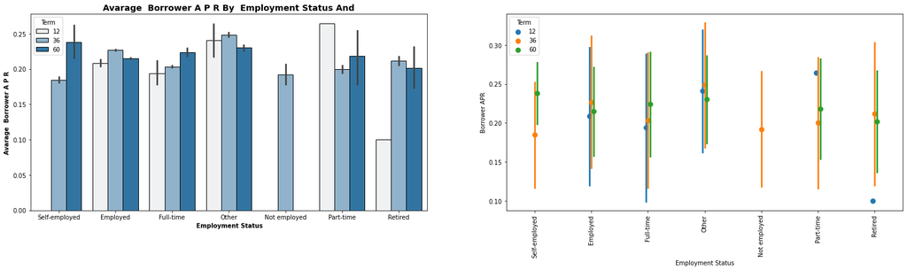

Self-employed borrowers who took 60 months plan have highest average Borrower's Annual Percentage Rate (APR) compared to average borrower rate of employed, part-time, retired etc of the same plan.

Part-time borrowers have the highest 12 months term average borrower rate ompared to average Borrower's Annual Percentage Rate (APR) of employed, part-time, retired etc of the same plan.

Also the mean Borrower rate Self-employed borrowers who take 36 months term is the lowest compared average Borrower's Annual Percentage Rate (APR) of employed, part-time, retired etc of the same plan.

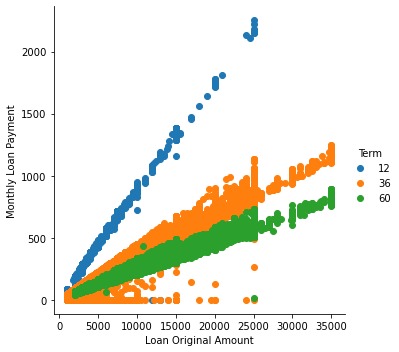

There is positive correlation between Monthly Loan Payment and Loan Original Amount. Borrowers who took 12 months term loan pay more loan every month than those who took 36 and 60 months plan.

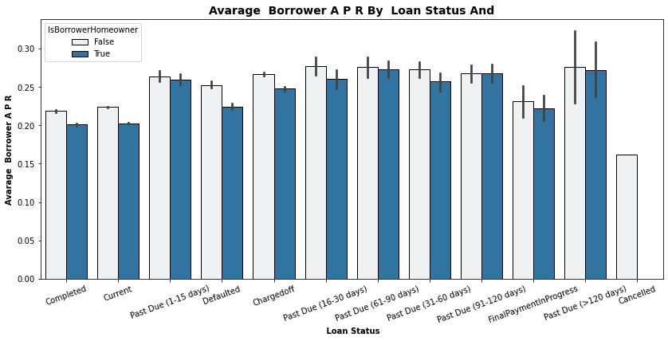

IsBorrowerHomeowner variable affect the relationship between loan status and Borrower's Annual Percentage Rate (APR). It seems borrowers who have competed loan and the current have lower Borrower's Annual Percentage Rate (APR) as compared to those who have defaulted. Homeowners borrowers who have completed,current and those who have defaulted their loans have lower borrower's annual percentage rate (APR) than those who are not homeowners.|

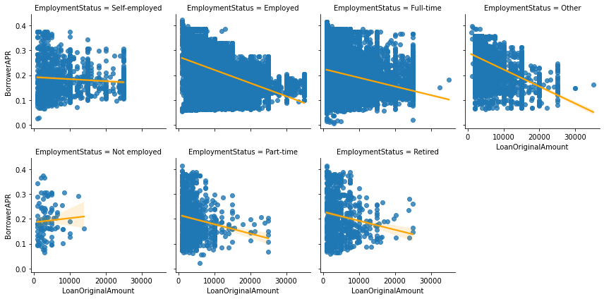